# DataSaurus_p66

## Visualización de solo la grafica del bullseye

En esta sección se muestra únicamente la gráfica correspondiente al conjunto de datos bullseye. Es posible observar varias elipses concéntricas, una dentro de otra, lo que le da una forma distintiva y resalta la particularidad de su distribución.

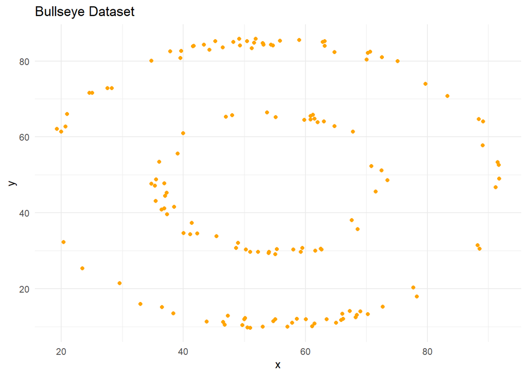

## Regresion lineal

En esta parte del análisis, se aplica un modelo de regresión lineal simple al conjunto de datos bullseye, utilizando la variable x como predictora de y. Para ello, se usa la función lm() de R, que ajusta una línea recta que mejor representa la relación entre ambas variables.

A continuación, se muestra un resumen del modelo ajustado, que incluye coeficientes, errores estándar y el valor de R², entre otros indicadores estadísticos.

Finalmente, se genera una visualización que superpone la línea de regresión (en rojo) sobre los datos originales (en azul), permitiendo evaluar visualmente el ajuste del modelo a la forma particular del conjunto bullseye.

```r
# Ajustar un modelo lineal
lm_model <- lm(y ~ x, data = bullseye_data)

# Resumen del modelo
summary(lm_model)
```

```
##
## Call:
## lm(formula = y ~ x, data = bullseye_data)
##
## Residuals:
##     Min      1Q  Median      3Q     Max
## -38.506 -23.548  -1.602  22.128  38.384
##
## Coefficients:
##             Estimate Std. Error t value Pr(>|t|)
## (Intercept)  53.8095     7.6904   6.997 9.92e-11 ***
## x            -0.1102     0.1354  -0.813    0.417
## ---
## Signif. codes:  0 '***' 0.001 '**' 0.01 '*' 0.05 '.' 0.1 ' ' 1
##
## Residual standard error: 26.97 on 140 degrees of freedom
## Multiple R-squared:  0.004704,   Adjusted R-squared:  -0.002405
## F-statistic: 0.6617 on 1 and 140 DF,  p-value: 0.4173
```

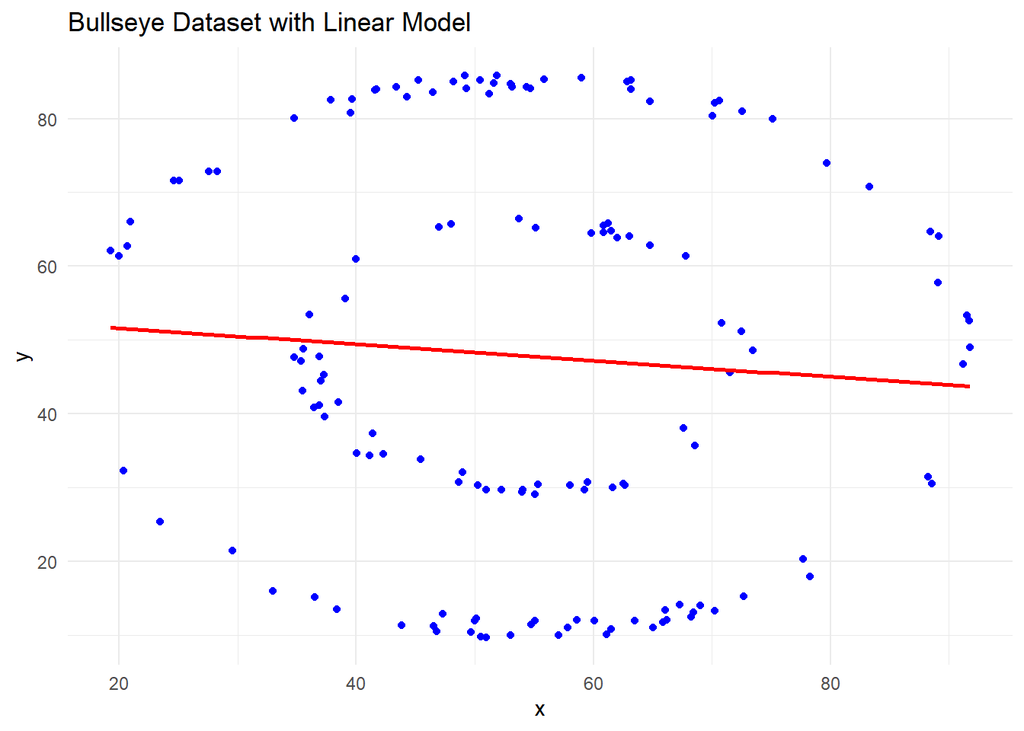

```r
# Graficar los datos con la línea de regresión
ggplot(bullseye_data, aes(x = x, y = y)) +
  geom_point(color = "blue") +           # Puntos de los datos
  geom_smooth(method = "lm", color = "red", se = FALSE) +  # Línea de regresión
  theme_minimal() +
  ggtitle("Bullseye Dataset with Linear Model")
```

## Regresión Lineal Manual

En esta sección se presenta una visualización previa a la implementación en R, donde se predice cómo sería la regresión lineal del dataset. Se puede notar que la dirección de la línea predicha se aproxima bastante a la del modelo calculado. Aunque la pendiente de la línea manual es ligeramente mayor, esta comparación permite confirmar que tanto el cálculo manual como el resultado en R muestran una similitud notable.

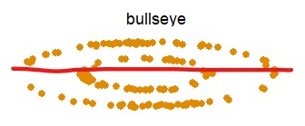